# 第九章 双变量回归与相关

x2yline

2017-10-28

## 知识清单

1. 直线回归
   - 相关概念
   - 求法
   - 统计推断
   - 区间估计
2. 直线相关
   - 相关概念
   - 求法
   - 统计推断
   - 决定系数
3. **直线回归应用注意事项**
4. 秩相关
5. *两回归直线的比较*
6. *曲线拟合*

## 1. 直线回归

### 1.1 基本概念

- 用途
  - 不是前几章的单变量，而是两个变量的关系
  - 数值变量或有序分类变量（秩相关）
- 直线方程及各值含义
  - 方程 1
    $$\hat{y}=a=bX$$
  - 方程 2
    $$\mu_{Y|X}=\alpha+\beta X$$
    - $\hat{y}$表示X对应Y的总体均数$\mu_{Y|X}$的一个样本估计，称预测值
    - a、b分别为$\alpha$和$\beta$的样本估计，a称为常数项，b称**回归系数**
    - b的统计意义是当X变化一个单位时Y的平均改变的估计值

### 1.2 计算方法

#### 1.2.1 理论计算

根据实测值Y与假定回归直线上的估计值$\hat{y}$的纵向距离$Y-\hat{y}$（残差）的平方和最小即最小二乘法可以推出
$$b=\frac{l_{XY}}{l_{XX}}=\frac{\sum{}{}(X-\bar{X})(Y-\bar{Y})}{\sum{}{}(X-\bar{X})^{2})}$$

$$a=\bar{Y}-b\bar{X}$$
式中$l_{XY}$为X与Y的离均差交叉乘积和，简称离均差积和

#### 1.2.2 R语言计算

```r
data9_1 <- haven::read_sav(
  file="E:\\医学统计学（第4版）\\各章例题SPSS数据文件\\例09-01.sav")
colnames(data9_1) <- c("age", "conc")
head(data9_1)
```

```
## # A tibble: 6 x 2
##     age  conc
##   <dbl> <dbl>
## 1    13  3.54
## 2    11  3.01
## 3     9  3.09
## 4     6  2.48
## 5     8  2.56
## 6    10  3.36
```

```r
line.model <- lm(conc~age, data=data9_1)
print(line.model)
```

```
##
## Call:
## lm(formula = conc ~ age, data = data9_1)
##
## Coefficients:
## (Intercept)          age
##      1.6617       0.1392
```

```r
line.model_summary <- summary(line.model)
```

### 1.3 统计推断

H0：$\beta=0$，即两变量直接无直线关系  
H1：$\beta \neq 0$，即两变量之间有线性关系

#### 1.3.1 方差分析

##### 公式

把Y的离均差平方和进行分解，分为回归平方和与残差平方和，其自由度分别为1，n-2。
$$Y-\bar{Y}=Y-\hat{Y}+\hat{Y}-\bar{Y}$$
$$\sum{}{}(Y-\bar{Y})^{2}=\sum{}{}(\hat{y}-\bar{Y})^{2} + \sum{}{}(Y-\hat{y})^{2}$$
$$SS_{总}=SS_{回}+SS_{残}$$

F值计算公式为（单侧F检验）：

$$F=\frac{SS_{回}/\nu_{回}}{SS_{残}/\nu_{残}},\ \nu_{回}=1,\ \nu_{残}=n-2$$

$SS_{回}$计算公式可以化简为：

$$SS_{回}=bl_{XY}=\frac{l_{XY}^{2}}{l_{XX}}=b^{2}l_{XX}$$

##### R语言实现

- 手动计算

```r
# 残差平方和
ss2 <- sum(line.model$residuals^2)
# 离均差平方和
ss0 <- var(data9_1$conc)*(nrow(data9_1)-1)
# 回归平方和
ss1 <- ss0-ss2
# F统计量
f.statistic <- (ss1/1)/(ss2/(nrow(data9_1)-2))
# p值
p <- pf(f.statistic, lower.tail=FALSE, df1=1, df2=nrow(data9_1)-2)
cat("F statistic is ", f.statistic, "\np value is ", p, sep="")
```

```
## F statistic is 20.96842
## p value is 0.003773985
```

- 直接调用查看summary.lm对象里的f值并转为p值

```r
f_df1_df2 <- summary(line.model)$fstatistic
p_value <- pf(f_df1_df2[1], df1=f_df1_df2[2], df2=f_df1_df2[3], lower.tail=F)
cat(cat("F statistic is ", f_df1_df2[1], "\np value is ", p_value, sep=""))
```

```
## F statistic is 20.96842
## p value is 0.003773985
```

- 直接打印sammary.lm对象，最后一行信息即为其F值和对应p值

```r
summary(lm(conc~age, data=data9_1))
```

```
##
## Call:
## lm(formula = conc ~ age, data = data9_1)
##
## Residuals:
##      Min       1Q   Median       3Q      Max
## -0.21500 -0.15937 -0.00125  0.09583  0.30667
##
## Coefficients:
##             Estimate Std. Error t value Pr(>|t|)
## (Intercept)  1.66167    0.29700   5.595  0.00139 **
## age          0.13917    0.03039   4.579  0.00377 **
## ---
## Signif. codes:  0 '***' 0.001 '**' 0.01 '*' 0.05 '.' 0.1 ' ' 1
##
## Residual standard error: 0.197 on 6 degrees of freedom
## Multiple R-squared:  0.7775, Adjusted R-squared:  0.7404
## F-statistic: 20.97 on 1 and 6 DF,  p-value: 0.003774
```

#### 1.3.2 t检验

t值计算公式：
$$t=\frac{b-0}{S_{b}},\ \nu=n-2$$

$$S_{b}=\frac{S_{Y\cdot X}}{\sqrt{l_{XX}}}$$

$$S_{Y\cdot X}=\sqrt{\frac{SS_{残}}{n-2}}$$

$S_{Y\cdot X}$为回归的剩余标准差，化简后有：

$$\sqrt{F}=t$$

R语言实现（双侧t检验）：

```r
lxx <- var(data9_1$age)*(nrow(data9_1)-1)
Sb <- sqrt(sum(line.model$residuals^2)/(nrow(data9_1)-2))/(sqrt(lxx))
t_statistic <- (line.model$coefficients[2]-0)/Sb
cat("t statistic is ", t_statistic, "\np value is ",
    2*pt(t_statistic, df=nrow(data9_1)-2, lower.tail=FALSE),
    sep="")
```

```
## t statistic is 4.579129
## p value is 0.003773985
```

#### 1.3.3 区间估计

- 总体回归系数$\beta$的可信区间 表示Y0的**均数**95%的置信区间

结合上述t检验的公式，$\beta$的$1-\alpha$可信区间为：
$$b\pm t_{\alpha/2,\ \nu}\cdot S_{b}$$

- 总体均数$\mu$的可信区间

$\hat{Y0}$会因**样本**（拟合的曲线）而异，其抽样误差大小的标准误：

$$S_{\hat{Y_{0}}}=S_{Y\cdot X}\sqrt{\frac{1}{n}+\frac{(X_{0}-\bar{X})^{2}}{\sum{}{}(X-\bar{X})^{2}}}$$

$\mu_{Y|X0}$的置信区间为：

$$\hat{Y_{0}} \pm t_{\alpha/2,\ \nu}\cdot S_{\hat{Y_{0}}}$$
R语言实现：

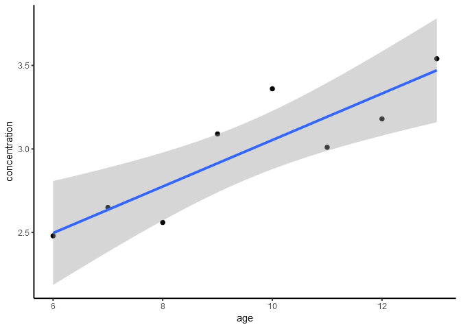

```r
lxx <- var(data9_1$age)*(nrow(data9_1)-1)
# 剩余标准差
syx <- sqrt(sum(line.model$residuals^2)/(nrow(data9_1)-2))
Sb <- syx/(sqrt(lxx))
t_statistic <- (line.model$coefficients[2]-0)/Sb

Sy01 <- syx*sqrt(1/nrow(data9_1)+
              (data9_1$age-mean(data9_1$age))^2/
              (var(data9_1$age)*nrow(data9_1)-1))

# geom_smooth自动加上了标准偏差即se=TRUE
library(ggplot2)
p <- ggplot(data9_1, aes(age, conc))+
  xlab("age")+ ylab("concentration")+
  geom_point(size=1.5)+
  geom_smooth(method="lm", se=TRUE)+
  theme_classic()
print(p)
```

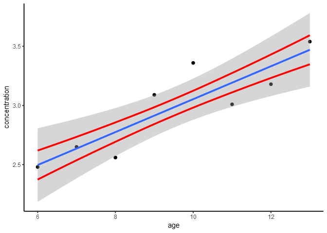

```r
p <- p + geom_smooth(aes(x=age, y=Sy01+
                   age*line.model$coefficients[2]+
                   line.model$coefficients[1]), color="red",
              se=FALSE, method="loess")+
  geom_smooth(aes(x=age, y=-Sy01+
                    age*line.model$coefficients[2]+
                    line.model$coefficients[1]), color="red",
              se=FALSE, method="loess")

print(p)
```

- 个体Y值的预测区间 表示**Y0值**的95%置信区间范围
  $$S_{Y_{0}}=S_{Y\cdot X}\sqrt{1+\frac{1}{n}+\frac{(X_{0}-\bar{X})^{2}}{\sum{}{}(X-\bar{X})^{2}}}$$

R语言实现：

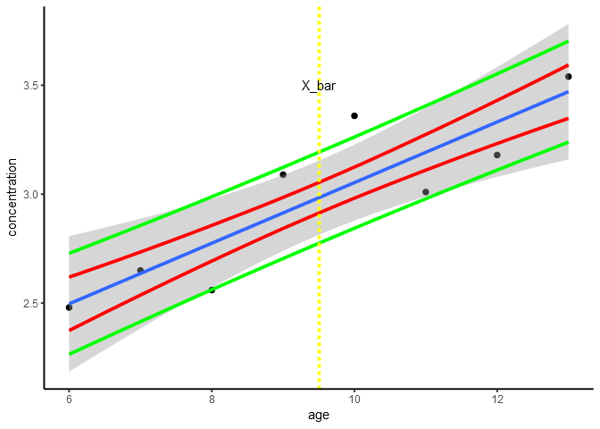

```r
lxx <- var(data9_1$age)*(nrow(data9_1)-1)
# 剩余标准差
syx <- sqrt(sum(line.model$residuals^2)/(nrow(data9_1)-2))
Sb <- syx/(sqrt(lxx))
t_statistic <- (line.model$coefficients[2]-0)/Sb

Sy02 <- syx*sqrt(1+1/nrow(data9_1)+
              (data9_1$age-mean(data9_1$age))^2/
              (var(data9_1$age)*nrow(data9_1)-1))

p + geom_smooth(aes(x=age, y=Sy02+
                   age*line.model$coefficients[2]+
                   line.model$coefficients[1]), color="green",
              se=FALSE, method="loess")+
  geom_smooth(aes(x=age, y=-Sy02+
                    age*line.model$coefficients[2]+
                    line.model$coefficients[1]), color="green",
              se=FALSE, method="loess")+
  geom_vline(xintercept=mean(data9_1$age), lwd=1, color="yellow", linetype=2)+
  annotate("text", x=mean(data9_1$age), y=3.5, label="X_bar")+
  guides(color = guide_legend(title = "LEFT", title.position = "left"))
```

## 2. 直线相关

### 2.1 相关概念

- 又称简单相关，用于双变量正态分布
- 相关系数（coefficient of correlation）又称Pearson积差相关系数（coefficient of product-moment correlation），符号$r$代表样本相关系数，符号$p$代表总体相关系数。

### 2.2 计算公式

以符号$r$表示样本相关系数，符号$\rho$表示总体相关系数，$r$是$rho$的估计，与b不同，它没有单位
$$r=\frac{\sum{}{}(X-\bar{X})(Y-\bar{Y})}{\sqrt{\sum{}{}(X-\bar(X))^{2}}\sqrt{\sum{}{}(Y-\bar{Y})^{2}}}=\frac{l_{XY}}{\sqrt{l_{XY}l_{YY}}}$$

R语言实现：

```r
data9_5 <- haven::read_sav(
  file="E:\\医学统计学（第4版）\\各章例题SPSS数据文件\\例09-05.sav")
colnames(data9_5) <- c("number", "age", "v")
# 公式法
r <- sum((data9_5$age-mean(data9_5$age))*(data9_5$v-mean(data9_5$v)))/
  sqrt(var(data9_5$age)*(nrow(data9_5)-1)*var(data9_5$v)*(nrow(data9_5)-1))
print(r)
```

```
## [1] 0.8754315
```

```r
# 包法
cor(data9_5$age, data9_5$v)
```

```
## [1] 0.8754315
```

### 2.3 统计推断

#### 2.3.1 t检验

H0：$\rho=0$
$$S_{r}=\sqrt{\frac{1-r^{2}}{n-2}},\ \nu=n-2$$
$$t=\frac{r-0}{S_{r}}$$

R语言实现：

```r
# 方法1：
Sr <- sqrt((1-r^2)/(nrow(data9_5)-2))
t_statistic <- (r-0)/Sr
pt(t_statistic, lower.tail=FALSE, df=nrow(data9_5)-2)*2
```

```
## [1] 1.910939e-05
```

```r
# 方法2：
cor.test(data9_5$v, data9_5$age)
```

```
##
##  Pearson's product-moment correlation
##
## data:  data9_5$v and data9_5$age
## t = 6.5304, df = 13, p-value = 1.911e-05
## alternative hypothesis: true correlation is not equal to 0
## 95 percent confidence interval:
##  0.6584522 0.9580540
## sample estimates:
##       cor
## 0.8754315
```

#### 2.3.2 可信区间

由于相关系数的抽样分布在$\rho$不等于0的情况下呈偏态分布，所以不能用t分布直接计算，向进行变量变换，使其服从正态分布在计算可信区间 * 对r作z反双曲正切函数变换：
$$z=tanh^{-1}r或z=\frac{1}{2}ln\frac{1+r}{1-r}$$
* 近似计算z的可信区间
$$(z-u_{\alpha/2/\sqrt{n-3}},\ z+u_{\alpha/2/\sqrt{n-3}})$$

- 变换z为r
  $$r=tanhz或r=\frac{e^{2z}-1}{e^{2z}+1}$$

R语言实现

```r
# 方法1：
z <- atanh(r)
u_0.05_2 <- qnorm(0.975, mean=0, sd=1)
r1 <- tanh(z-u_0.05_2/sqrt(nrow(data9_5)-3))
r2 <- tanh(z+u_0.05_2/sqrt(nrow(data9_5)-3))
cat("CL is ", r1, "~", r2, sep="")
```

```
## CL is 0.6584522~0.958054
```

```r
# 方法2：
cor.test(data9_5$age, data9_5$v, conf.level=0.95, alternative="two.sided")
```

```
##
##  Pearson's product-moment correlation
##
## data:  data9_5$age and data9_5$v
## t = 6.5304, df = 13, p-value = 1.911e-05
## alternative hypothesis: true correlation is not equal to 0
## 95 percent confidence interval:
##  0.6584522 0.9580540
## sample estimates:
##       cor
## 0.8754315
```

### 2.4 决定系数

定义：回归平方和与总平方和之比，计算公式为

$$R^{2}=\frac{SS_{回}}{SS_{总}}=\frac{l_{XY}^{2}/l_{XX}}{l_{YY}}$$
对于双变量回归分析，$R^{2}$即$r^{2}$，处可以概括拟合效果外，还可以作假设检验

$$F=\frac{R^{2}}{(1-R^{2})(n-2)}=\frac{SS_{回}}{SS_{残}/\nu_{残}}=\frac{MS_{回}}{MS_{残}}$$

R语言实现：

```r
data9_5 <- haven::read_sav(
  file="E:\\医学统计学（第4版）\\各章例题SPSS数据文件\\例09-05.sav")
colnames(data9_5) <- c("number", "age", "v")
line.model <- lm(v~age, data=data9_5)
r.squared <- summary(line.model)$r.squared
print(r.squared)
```

```
## [1] 0.7663803
```

```r
adj.r.squared <- summary(line.model)$adj.r.squared
print(adj.r.squared)
```

```
## [1] 0.7484095
```

```r
r.squared <- 1-var(line.model$residuals)*(nrow(data9_5)-1)/
  (var(data9_5$v)*(nrow(data9_5)-1))
print(r.squared)
```

```
## [1] 0.7663803
```

```r
f.statistic <- (r.squared)/((1-r.squared)/(nrow(data9_5)-2))
print(f.statistic)
```

```
## [1] 42.64598
```

```r
summary(line.model)$fstatistic
```

```
##    value    numdf    dendf
## 42.64598  1.00000 13.00000
```

## 3. 直线回归应用注意事项

- 根据目的选择变量及统计方法（自变量和因变量，如重测信度评价的相关系数，r应达到0.40以上
- 进行相关，回归分析前应绘制散点图，离群值
- 结果解释
  - 相关系数或回归系数的绝对值反映密切程度
  - p值越小越有理由认为变量间的直线关系存在
- 残差图观察是否符合模型假设的条件：自变量与因变量关系为线性，误差服从均数为0的正态分布，且方差相等，各观测独立(**残差图横坐标为$\hat{Y}$或者X，纵坐标为残差**)
  - 正常为在y=0处对称分布，并且左右对称
  - 离群值会与群体远离
  - 喇叭状（左右不对称）说明方差不齐（须稳定化处理）
  - 呈曲线则可能是符合曲线模型
  - 呈直线说明残差与时间存在相关
- R语言实现残差图

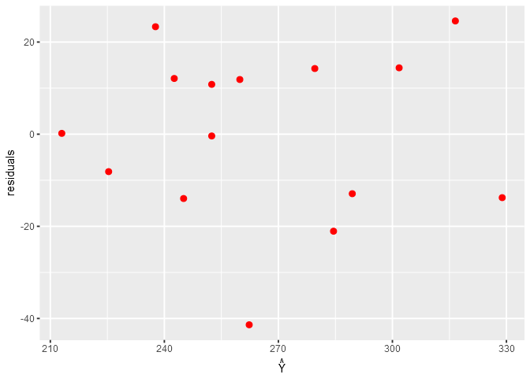

```r
data9_5 <- haven::read_sav(
  file="E:\\医学统计学（第4版）\\各章例题SPSS数据文件\\例09-05.sav")
colnames(data9_5) <- c("number", "age", "v")
line.model <- lm(v~age, data=data9_5)
# +geom_point(aes(age, v), size=1.5)+
#   geom_smooth(aes(age, v), method="lm")+
library(ggplot2)
ggplot(data9_5)+
  geom_point(aes(x=predict(line.model), y=residuals(line.model)), color="red", size=2)+
  ylab("residuals")+xlab(latex2exp::TeX("$\\hat{Y}$"))
```

残差图没有明显的偏倚趋势（**各区域残差的变异程度大致相同**），说明残差至少在一定的范围内是恒定的，该线性模型的效果基本还行

## 4. 秩相关

### 4.1 适用条件

> 不服从双变量正态分布，而不宜做积差相关分析（散点图或统计表看出）

> 总体分布类型未知

> 原始数据用等级表示

### 4.2 Spearman秩相关

#### 等级相关系数公式

$d$是指两个变量的秩差，完全正相关则$\sum{}{}d_{i}^{2}$有最小值为0，完全负相关则$\sum{}{}d_{i}^{2}$有最大值为$\frac{n(n^{2}-1}{3}$，0相关则则$\sum{}{}d_{i}^{2}=\frac{0+\frac{n(n^{2}-1}{3}}{2}=\frac{n(n^{2}-1}{6}$，有以下公式

$$r_{s}=1-\frac{6\sum{}{}d^{2}}{n(n^{2}-1)}$$

$r_{s}$介于-1与1之间，负数则为负相关，正数则为正相关，0则0相关 #### 统计推断 样本等级相关系数$r_{s}$是总体相关系数$\rho_{s}$的估计值，检验$\rho_{s}$是否不为0可以用查表法，如果n大于50，可以用u检验，其中$u=r_{s}\sqrt{n-1}$，查u界值确定p

> 相同秩较多的情况下，需要校正，也可以不校正直接进行秩的pearson相关系数的计算

#### R语言实现

```r
data9_8 <- haven::read_sav(
  file="E:\\医学统计学（第4版）\\各章例题SPSS数据文件\\例09-08.sav")
colnames(data9_8) <- c("number", "X", "Y")
# 默认method为pearson，如果有相同秩，会自动校正
1-sum((rank(data9_8$X)-rank(data9_8$Y))^2)*6/(nrow(data9_8)^3-nrow(data9_8))
```

```
## [1] 0.9050568
```

```r
cor(data9_8$X, data9_8$Y, method="spearman")
```

```
## [1] 0.9050568
```

```r
cor.test(data9_8$X, data9_8$Y, method="spearman")
```

```
##
##  Spearman's rank correlation rho
##
## data:  data9_8$X and data9_8$Y
## S = 92, p-value < 2.2e-16
## alternative hypothesis: true rho is not equal to 0
## sample estimates:
##       rho
## 0.9050568
```

```r
# 模拟有相同秩的情况
a <- c(1, 2, 3.5, 3.5, 5, 6)
b <- c(2, 1, 3, 4, 5.5, 5.5)
1-sum((rank(a)-rank(b))^2)*6/(length(a)^3-length(a))
```

```
## [1] 0.9142857
```

```r
cor(a, b, method="spearman")
```

```
## [1] 0.9117647
```

> cor函数还有一个use参数来处理数据缺失的情况（NA)，默认为use=“all.obs”，该情况下，如果数据有缺失，则报错，可以修改为use=“complete.obs”，把含缺失数据的那一列删除后再运行，或者修改为use=“pairwise.complete.obs”，把含缺失数据的那一行删除后再运行

参考：  
https://www.statmethods.net/stats/correlations.html